# SL_PRJ2_HEALTHCARE_WEEK2

```python
# import library
import numpy as np
import pandas as pd
import math
import matplotlib.pyplot as plt
import seaborn as sns
from matplotlib import style
%matplotlib inline
```

```python
data = pd.read_csv('health care diabetes.csv')
```

**Question***

1. Check the balance of the data by plotting the count of outcomes by their value. Describe your findings and plan future course of action.

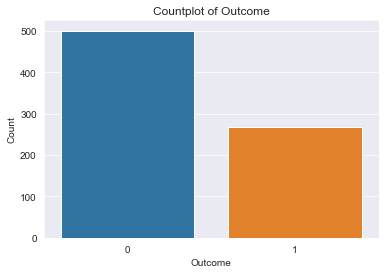

```python
sns.set_style('darkgrid')
sns.countplot(data['Outcome'])
plt.title("Countplot of Outcome")
plt.xlabel('Outcome')
plt.ylabel("Count")
```

We can see that value (1 - Diabetes) is more than 50% of value 0(non-diabetes). SO data is balanced. I am taking into account - 30% as the relative standard, if one of the data is less than 30% of the other data, then we can consider data as imbalanced and we need to consider sampling techniques for better model accuracy. But here we can take the data As it is for model building and classification alogirthms.

***Question*

Create scatter charts between the pair of variables to understand the relationships. Describe your findings.

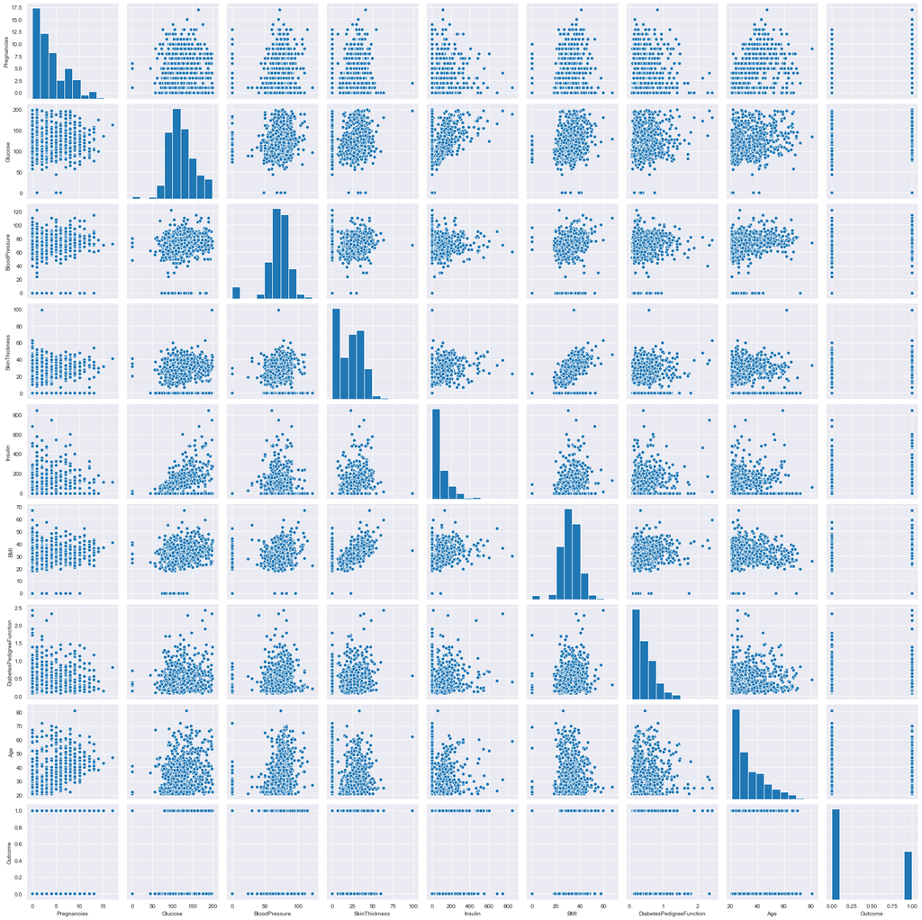

```python
sns.pairplot(data)
```

The above dashboard contains more number of charts and very difficult to analyze. So lets also split and do for couple of variable pairs that seem to have better correlation

```python
data1 = data[['BMI','SkinThickness']]
data2 = data[['Insulin','SkinThickness']]
```

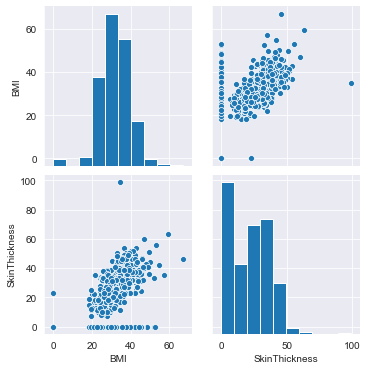

```python
sns.pairplot(data1)
```

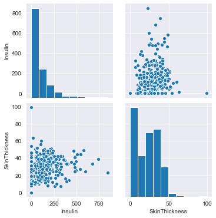

```python
sns.pairplot(data2)
```

'SkinThickness' has a good/decent correlation with 'Insulin' and 'BMI'

**Question***

1. Perform correlation analysis. Visually explore it using a heat map.

```python
data.corr()
```

|  | Pregnancies | Glucose | BloodPressure | SkinThickness | Insulin | BMI | DiabetesPedigreeFunction | Age | Outcome |
| --- | --- | --- | --- | --- | --- | --- | --- | --- | --- |
| Pregnancies | 1.000000 | 0.129459 | 0.141282 | -0.081672 | -0.073535 | 0.017683 | -0.033523 | 0.544341 | 0.221898 |
| Glucose | 0.129459 | 1.000000 | 0.152590 | 0.057328 | 0.331357 | 0.221071 | 0.137337 | 0.263514 | 0.466581 |
| BloodPressure | 0.141282 | 0.152590 | 1.000000 | 0.207371 | 0.088933 | 0.281805 | 0.041265 | 0.239528 | 0.065068 |
| SkinThickness | -0.081672 | 0.057328 | 0.207371 | 1.000000 | 0.436783 | 0.392573 | 0.183928 | -0.113970 | 0.074752 |
| Insulin | -0.073535 | 0.331357 | 0.088933 | 0.436783 | 1.000000 | 0.197859 | 0.185071 | -0.042163 | 0.130548 |
| BMI | 0.017683 | 0.221071 | 0.281805 | 0.392573 | 0.197859 | 1.000000 | 0.140647 | 0.036242 | 0.292695 |
| DiabetesPedigreeFunction | -0.033523 | 0.137337 | 0.041265 | 0.183928 | 0.185071 | 0.140647 | 1.000000 | 0.033561 | 0.173844 |
| Age | 0.544341 | 0.263514 | 0.239528 | -0.113970 | -0.042163 | 0.036242 | 0.033561 | 1.000000 | 0.238356 |
| Outcome | 0.221898 | 0.466581 | 0.065068 | 0.074752 | 0.130548 | 0.292695 | 0.173844 | 0.238356 | 1.000000 |

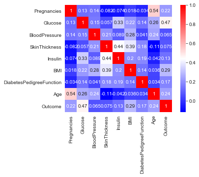

```python
sns.heatmap(data.corr(), square=True, cmap='bwr', annot=True);
```

From the heatmap, below inferences are made:

   [Skin Thickness, Insulin], [Skin Thickness, BMI], [Insulin, Glucose], [BMI, BloodPressure]